# Review of Common Probability Distributions

Steve Elston

09/15/2022

# Importance of Probability Theory

- Probability theory is the basis of statistics, machine learning, and much AI
- An understanding of probability theory is an important foundation to understand these methods
- In this lesson we will review some basic concepts
  - Properties of probability distributions
  - Some commonly used probability distributions - focus on difficult to understand properties
- Many texts provide comprehensive introductions to probability theory

# Probability Theory Has a Long History

- First probability textbook by Jacob Bernoulli, published posthumously in 1713

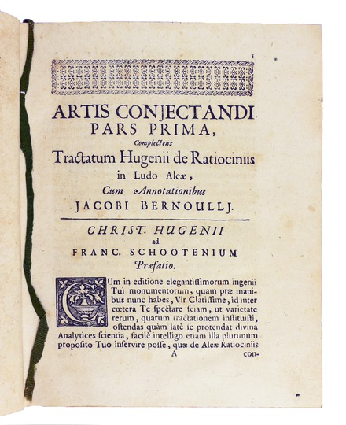

First probability textbook Credit, Wikipedia commons

- Probability theory is still an active area of research

# Probability Distributions

**Probability distributions** are models for uncertainty of **random variables**

- A random variable is any **mapping**, $X$, from from some outcome of a random event, $\omega$, to a real number, $\mathbb{R}$:

$$X(\omega) \rightarrow
\mathbb{R}$$

- **Example:** The mapping can be a count
- **Example:** A function which transforms $\omega$ to a real number, $\mathbb{R}$
- This concept appears abstract at first glance, but is fundamental to the theory of probability
- We will see many examples in this course

# Two Types of Probability Distributions

- **Discrete**
  - Model countable events
  - Examples; people making a purchase, number of patients with disease,….
  - Characterized by a **probability mass function (PMF)**
- **Continuous**
  - Examples; temperature, velocity, price,…….
  - Characterized by a **probability density function (PDF)**

# Axioms of Probability

For discrete distributions, we can speak of a **set of events** within the **sample space** of all possible events

1. Probability for any set of events, A, is greater than 0 and less than or equal to 1

$$0 \le P(A) \le 1$$

2. The sum of the probability mass functions over the sample space must add to 1

$$P(S) = \sum_{a_i \in A}P(a_i) = 1$$

3. If sets of events A and B are mutually exclusive, then the probability of either A and B is the probability of A plus the probability of B

$$P(A\ \cup B) = P(A) + P(B)\\ if\ A \perp
B$$

# Axioms of Probability

From these three axioms we can draw some useful conclusions

- Events which cannot occur have probability 0
- Events that must occur have probability 1
- Events must have a probability mass function between 0 and 1

# What do you expect: discrete distributions

What value we should expect to find when we sample a random variable?

- This is the **expected value** or simply the **expectation**
- For $n$ samples, $\mathbf{X} = x_1, x_2, \ldots, x_n$, of a random variable probability mass function $p(x_i)$ the expected value is:

$$\mathrm{E}[\mathbf{X}] = \sum_{i=1}^n
x_i\ p(x_i)$$

How can we interpret expectation?

- Expectation is a probability weighted sum of the sample of the random variable $\mathbf{X}$
- By the second axiom of probability the weights must sum to 1.0

# Properties of Expectation

Useful properties of expectation

1. The relationship is linear in probability
2. The expectation of the sum of two random variables, $X$ and $Y$, is the sum of the expectations:

$$\mathrm{E}[\mathbf{X,Y}] =
\mathrm{E}[\mathbf{X}] + \mathrm{E}[\mathbf{Y}]$$

3. The expectation of an **affine transformation** of a random variable, $X$, is an **affine transformation** of the expectation:

$$\mathrm{E}[\mathbf{a\ X + b}] = a\
\mathrm{E}[\mathbf{X}] + b$$

# Axioms of probability for continuous distributions

**Axioms of probability** for continuous probability density function, $f(x)$

1. On the interval, $\{ x_1, x_2 \}$, $P(x)$, must be bounded by 0 and 1:

$$0 \le \int_{x_1}^{x_2} f(x) dx\ \le
1$$

Note: if $x_1 = x_2$ the integral is 0

2. The area under the entire PDF over the limits must be equal to 1:

$$\int_{lower}^{upper} f(x) dx =
1$$

Note: many distributions lower = $0$ or $-\infty$ and upper = $\infty$

3. If events A and B are mutually exclusive:

$$P(A\ \cup B) = P(A) + P(B)\ \\ if\ A
\perp B$$

# What do you expect: continuous distributions

**Expected value** with PDF $f(x)$, over the interval, $\{ a, b \}$:

$$\mathrm{E}[\mathbf{X}] = \int_{a}^b x\
f(x)\ dx$$

- Values $x$ are weighted by the PDF
- By the second axiom of probability presented above, PDF must equal 1.0 integrated over the entire range of $x$
- Transformation of expectation is same as for discrete random variables

# Bernoulli and Binomial Distributions

Bernoulli distributions model the results of a **single trial** or **single realization** with a binary outcome

- For outcomes $\{ 0,1 \}$, or $\{ failure, success \}$, with probability $p$ of success:

$$\begin{align}
P(x\ |\ p) &= \bigg\{
\begin{matrix}
p\ if\ x = 1\\
(1 - p)\ if\ x = 0
\end{matrix}\\
or\\
P(x\ |\ p) &= p^x(1 - p)^{(1-x)}\ x \in {0, 1}
\end{align}$$

- Model the number of successful outcome in $N$ trials with the **Binomial distribution**
- Binomial distribution is product of multiple Bernoulli trials:

$$P(k\ |\ N, p) = \binom{N}{k} p^k(1 -
p)^{(N-k)}$$

- Product of Bernoulli trials is normalized by the [**Binomial coefficient**](https://en.wikipedia.org/wiki/Binomial_coefficient#Factorial_formula)

# Distributions for Multiple Outomes; the Categorical and Multinomial Distribution

Many real-world cases have many possible outcomes

- In these cases need a probability distribution for multiple outcomes
- **Categorical distribution** models multiple outcomes
- Categorical Distribution is the multiple-outcome extension of the Bernoulli distribution, and is sometimes call the **Multinoulli distribution**.

# The Categorical distribution

Sample space of $k$ possible outcomes, $\mathcal{X} = (e_1,e_2, \ldots, e_k)$.

- For each trial, there can only be one outcome
- For outcome $i$ we can encode the results as:

$$\mathbf{e_i} = (0, 0, \ldots, 1, \ldots,
0)$$

- Only $1$ value $e_i$ has a value of $1$; **one hot encoding**
- For a single trial the probabilities of the $k$ possible outcomes are expressed:

$$\begin{align}
\Pi &= (\pi_1, \pi_2, \ldots, \pi_k) \\ \\
with\ \sum_{i}\pi_i &= 1
\end{align}$$

# The Categorical distribution

And consequently, we can write the simple probability mass function as:

$$f(x_i| \Pi) = \pi_i$$

For a series $n$ of trials we can estimate each of the probabilities of the possible outcomes, $(\pi_1, \pi_2, \ldots, \pi_k)$:

$$\pi_i = \frac{\#\ e_i}{n}$$

Where $\#\ e_i$ is the count of outcome $e_i$.

# The Categorical distribution

For the case of $k=3$ you can visualize the possible outcomes of a single Categorical trial

- Each discrete outcome must fall at one of the corners of a **simplex**
- The probabilities of of each outcome is $(\pi_1, \pi_2, \pi_3)$.

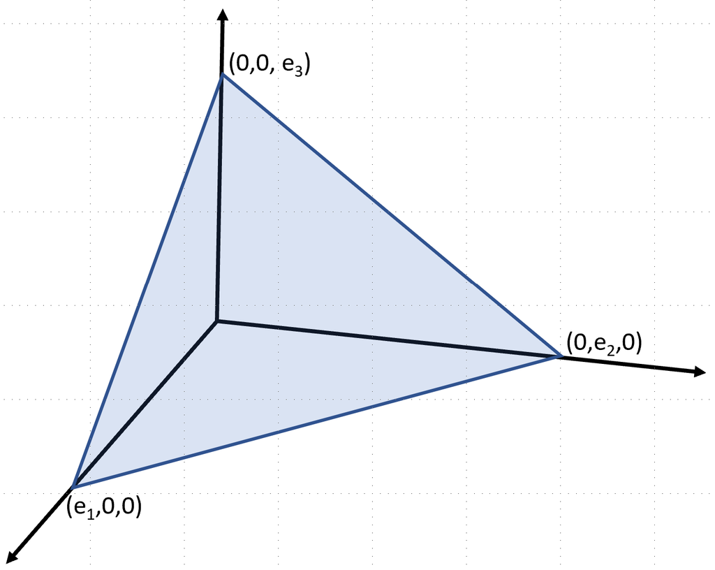

Simplex for $Mult_3$

# Normal distribution

The **Normal distribution** or **Gaussian distribution** is one of the most widely used probability distributions

- The distribution of mean estimates of observations of a random variable drawn from any distribution converge to a Normal distribution by the **central limit theorem (CLT)**
- Many physical processes produce Normal measurement values
- Normal distribution has tractable mathematical properties

# Normal distribution

For a univariate Normal distribution we can write the density function as:

$$P(x) = \frac{1}{\sqrt{2 \pi \sigma^2}}
\exp{\frac{-(x - \mu)^2}{2 \sigma^2}}$$

The parameters can be interpreted as:

$$\begin{align}
\mu &= location\ parameter = mean \\
\sigma &= scale = standard\ deviation \\
\sigma^2 &= Variance
\end{align}$$

# Multivariate Normal

Many practical applications have an $n$-dimensional parameter vector in $\mathbb{R}^n$, requiring **multivariate distributions**

- **Multivariate Normal distribution**, parameterized by:
- **n-dimensional vector of locations**, $\vec{\mathbf{\mu}}$
  - The vector(multi) valued version of univariate location
- $n$ x $n$ dimensional **covariance matrix**, $\mathbf{\Sigma}$
  - The multi-dimensional version of univariate variance $\sigma^2$

$$f(\vec{\mathbf{x}}) = \frac{1}{{\sqrt{(2
\pi)^n |\mathbf{\Sigma}|}}}exp \big(\frac{1}{2} (\vec{\mathbf{x}} -
\vec{\mathbf{\mu}})^T \mathbf{\Sigma} (\vec{\mathbf{x}} -
\vec{\mathbf{\mu}})\big)$$

- $|\mathbf{\Sigma}|$ is the determinant of the covariance matrix.
- Along the diagonal the values are the $n$ variances of each dimension, $\sigma_{i,i}$
- Off-diagonal terms describe the **dependency** between the $n$ dimensions of the distribution.

# Multivariate Normal

We can write the covariance matrix:

$$\mathbf{\Sigma} =
\begin{bmatrix}
\sigma_{1,1} & \sigma_{1,2} & \ldots & \sigma_{1,n} \\
\sigma_{2,1} & \sigma_{2,2} & \ldots & \sigma_{2,n} \\
\vdots & \vdots & \vdots & \vdots \\
\sigma_{n,1} & \sigma_{n,2} & \ldots & \sigma_{n,n} \\
\end{bmatrix}$$

For a Normally distributed n-dimensional multivariate random variable, $\sigma_{i,j}$ computed from the sample, $\mathbf{X}$:

$$\begin{align}
\sigma_{i,j} &= \mathrm{E} \big[ (\vec{x}_i - \mathrm{E}[\vec{x}_i])
\cdot (\vec{x}_j - \mathrm{E}[\vec{x}_j]) \big] \\
&= \mathrm{E} \big[ (\vec{x}_i - \bar{x}_i) \cdot (\vec{x}_j -
\bar{x}_j) \big] \\
&= \frac{1}{k}(\vec{x}_i - \bar{x}_i) \cdot (\vec{x}_j - \bar{x}_j)
\end{align}$$

Where $\cdot$ is the inner product operator and $\bar{x_i}$ is the mean of $\vec{x_i}$.

# Multivariate Normal

2-dimensional Normal with $\mu = [0,0]$ and $\sigma = \begin{bmatrix} 1.0 & 0.0 \\ 0.0 & 1.0 \end{bmatrix}$

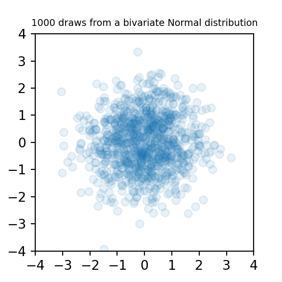

# Multivariate Normal

2-dimensional Normal with $\mu = [0,0]$ and $\sigma = \begin{bmatrix} 1.0 & 0.0 \\ 0.0 & 0.5 \end{bmatrix}$

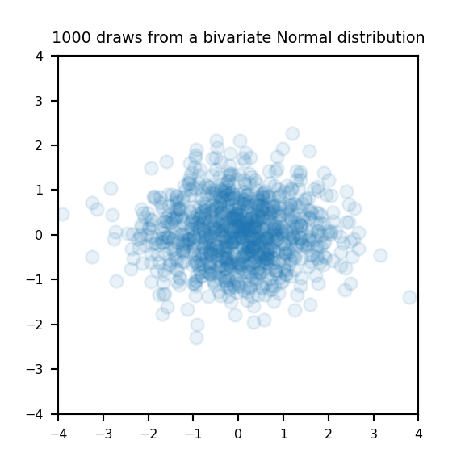

# Multivariate Normal

2-dimensional Normal with $\mu = [0,0]$ and $\sigma = \begin{bmatrix} 1.0 & 0.5 \\ 0.5 & 1.0 \end{bmatrix}$

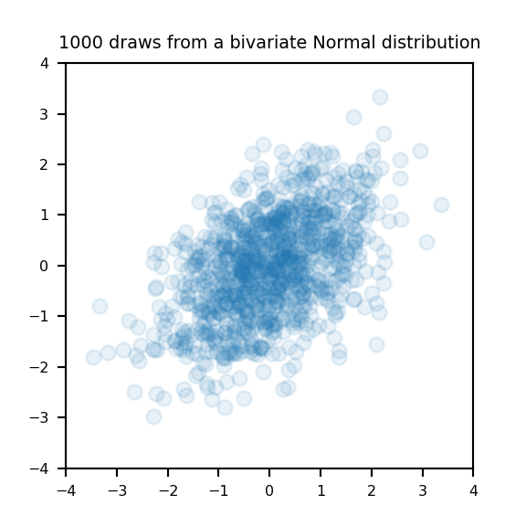

# Multivariate Normal

2-dimensional Normal with $\mu = [0,0]$ and $\sigma = \begin{bmatrix} 1.0 & -0.5 \\ -0.5 & 1.0 \end{bmatrix}$

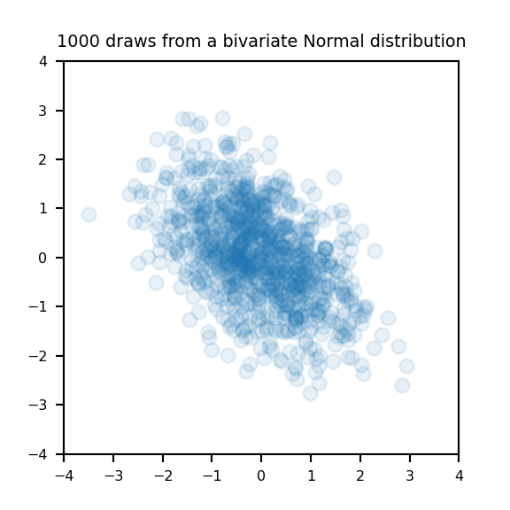

# Multivariate Normal

2-dimensional Normal with $\mu = [0,0]$ and $\sigma = \begin{bmatrix} 1.0 & 0.9 \\ 0.9 & 1.0 \end{bmatrix}$

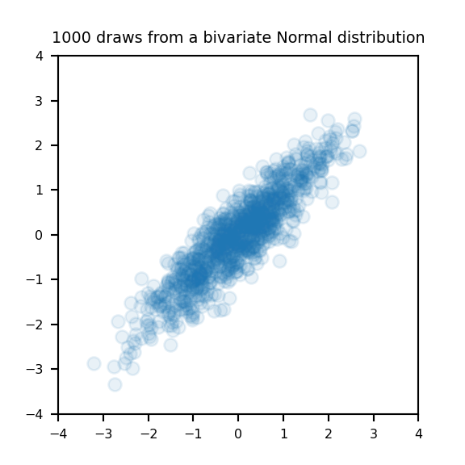

# Log-Normal distribution

Log Normal distribution is defined for continuous random variables in the range $0 < x \le \infty$  
- Examples price, weight, length, and volume

- The Log-Normal distribution is based on a log-transformation of the random variable:

$$P(x) = \frac{1}{x} \frac{1}{\sigma
\sqrt{2 \pi}} \exp{\frac{-(log(x) - \mu)^2}{2 \sigma^2}}$$

# Student t-distribution

[**Student t-distribution**](https://en.wikipedia.org/wiki/Student%27s_t-distribution), or simply the t-distribution, is of importance in statistics since it is the distribution of the difference of means of two Normally distributed random variables

- t-distribution has one parameter, the **degrees of freedom**, denoted as $\nu$
- The PDF of the t-distribution is a rather complex looking result:

$$P(x\ |\ \nu) = \frac{\Gamma(\frac{\nu + 1}{2})}{\sqrt{\nu \pi}
\Gamma(\frac{\nu}{2})} \bigg(1 + \frac{x^2}{\nu} \bigg)^{- \frac{\nu +
1}{2}}\\
where\\
\Gamma(x) = Gamma\ function$$

# The Gamma and $\chi^2$ distributions

**Gamma family of distributions** includes several members which are important in statistics

- Gamma distributions are a two-parameter exponential family
- PDF is defined in the range $0 \le x \le \infty$
- Gamma family are used in problems, ranging from measurements of physical systems to hypothesis testing

# The Gamma and $\chi^2$ distributions

Gamma family can be parameterized in several ways; we will use:  
- A shape parameter, $\nu$, the degrees of freedom  
- A scale parameter, $\sigma$

$$Gam(\nu,\sigma)=\frac{x^{\nu-1}\ e^{-x/\sigma}}{\sigma^\nu\
\Gamma(\nu)}\\
where\\
x \ge 0,\ \nu > 0,\ \sigma > 0\\
and\\
\Gamma(\nu) = Gamma\ function$$

- Alternatively, use an inverse scale parameter, $\beta = 1/\sigma$.

# The Gamma and $\chi^2$ distributions

Two useful special cases of the Gamma distribution are:

- $Gam(1,1/\lambda)$ is the **exponential distribution** with decay constant $\lambda$, and PDF:
  $$exp(\lambda) = \lambda e^{-\lambda
  x}$$
- $Gam(\nu/2,2) = \chi^2_\nu$ is the **Chi-squared distribution** with $\nu$ degrees of freedom The $\chi^2_\nu$ distribution has many uses in statistics.
  - Used for estimates of the variance of the Normal distribution
  - PDF of the $\chi^2_\nu$ distribution:
    $$\chi^2_\nu=\frac{x^{\nu/2-1}\
    e^{-x}}{\sigma^{\nu/2}\ \Gamma(\nu/2)}\\ for\ \nu\ degrees\ of\
    freedom$$

# Odds

**Odds** are the ratio of the number of ways an event occurs to the number of ways it does not occur

- Can say that **odds** are the count of events in favor of an event vs. the count against the event
- **Example:** Flip a fair coin, odds of getting heads are $1:1$ (1 in 1)
- **Example:** Roll a single fair die your odds of rolling a 6 are $1:5$ (1 in 5), or 0.2

# Odds

What is the relationship between odds and probability of an event?

- For some event with count $A$ in a set of all outcomes with count $S$, and count of negative outcomes $B = S - A$:

$$P(A) = \frac{A}{S} = \frac{A}{A + (S -
A)} = \frac{A}{A + B} = \frac{count\ in\ favor}{count\ in\ favor\ +
count\ not\ in\ favor}\ \\
which\ implies\\
odds = A:(S-A)$$

- **Example:** For the fair coin flip, the odds are $1:1$. So we can compute the probability of heads as:

$$P(H) = \frac{1}{1 + 1} =
\frac{1}{2}$$

- **Example** In statistics the [**odds ratio**](https://en.wikipedia.org/wiki/Odds_ratio), $\frac{p}{1-p}$, used to predict the response variable in logistic regression

# Summary

- Axioms of probability; for discrete distribution

$$0 < P(A) \le 1$$
$$P(S) = \sum_{a_i \in A}P(a_i) = 1$$
$$P(A\ \cup B) = P(A) + P(B)\\ if\ A \perp
B$$

- Expectation

$$\mathrm{E}[\mathbf{X}] = \sum_{i=1}^n
x_i\ p(x_i)$$

# Summary

- The Categorical distribution
  - For outcome $i$ we **one hot encode** the results as:
    $$\mathbf{e_i} = (0, 0, \ldots, 1, \ldots,
    0)$$
  - For a single trial the probabilities of the $k$ possible outcomes are expressed:
    $$\Pi = (\pi_1, \pi_2, \ldots,
    \pi_k)$$
  - probability mass function as:

$$f(x_i| \Pi) = \pi_i$$

- Multivariate Normal distribution, parameterized by **n-dimensional vector of locations**, $\vec{\mathbf{\mu}}$ and $n$ x $n$ dimensional **covariance matrix**
  $$f(\vec{\mathbf{x}}) =
  \frac{1}{{\sqrt{(2 \pi)^k |\mathbf{\Sigma}|}}}exp \big(\frac{1}{2}
  (\vec{\mathbf{x}} - \vec{\mathbf{\mu}})^T \mathbf{\Sigma}
  (\vec{\mathbf{x}} - \vec{\mathbf{\mu}})\big)$$